# stat992HW1

SongWang

10/08/2015

### read the referral/ physisian feature/payment data sets

and select a subset from it conditional on the state = CA, City = “San Francisco”, entity_type = “individual”

```r
rm(list=ls())
library(data.table)  # so fast!
# install.packages('igraph')
library(igraph)  # all the basic graph operations.
##############
setwd("~/Stat/Courses/Physisian_Referral_Network")
DataPath <- "./Data/"
ResultsPath <- "./Results/"
PlotsPath <- "./Plots/"
RScriptsPath <- "./RScripts/"


#### payment data

# Payment = fread(paste0(DataPath,
#       "Medicare_Provider_Util_Payment_PUF_CY2013/Medicare_Provider_Util_Payment_PUF_CY2013.txt"),
#                 sep = "\t")
# Payment <- Payment[-1]
# setkey(Payment, NPI)
# head(Payment)
#
# Payment_NPI_ca <- Payment[NPPES_PROVIDER_STATE=="CA"&NPPES_ENTITY_CODE=="I"]
# Payment_NPI_total_ca= Payment_NPI_ca[,.(NPI,totalPay=AVERAGE_MEDICARE_ALLOWED_AMT * LINE_SRVC_CNT)]
# Payment_NPI_total_ca <- Payment_NPI_total_ca[,.(totalPay=sum(totalPay)),by=NPI]
#
# save(Payment_NPI_total_ca,file = paste0(DataPath, "Payment_NPI_total_ca.RData"))


system.time(load(paste0(DataPath, "EtDT.RData")))
```

```
##    user  system elapsed
##  60.356   0.517  60.986
```

```r
system.time(load(paste0(DataPath,"Payment_NPI_ca.RData"))) ## payment data constrained to individual physisian in CA
```

```
##    user  system elapsed
##   4.107   0.062   4.229
```

```r
system.time(load(paste0(DataPath,"Payment_NPI_total_ca.RData")))
```

```
##    user  system elapsed
##   0.006   0.000   0.008
```

```r
## Payment_NPI_total_ca
## physisian --individual  & in ca
NPI_SF <- DT[City=="SAN FRANCISCO" & NPI%in%Payment_NPI_total_ca$NPI ]
setkey(NPI_SF,NPI)
#NPI_SF = NPI_SF[unique(NPI_SF$NPI), mult="first"]
Edge_SF <- Et[V1 %in% unique(NPI_SF$NPI)]
setkey(Edge_SF, V1)

setkey(Payment_NPI_total_ca,NPI)
Payment_SF <- Payment_NPI_total_ca[NPI%in%NPI_SF$NPI]
Payment_SF <- Payment_SF[,.(NPI,totalPay,logPay = log(totalPay+1))]
```

### Part 1.1 Look at the positions of Physician in San Francisco.

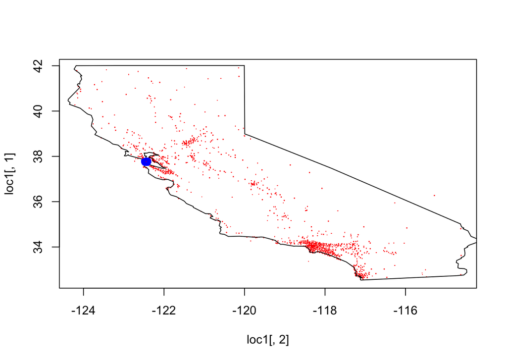

```r
library(zipcode)
library(data.table)
data(zipcode)   # this contains the locations of zip codes
setkey(NPI_SF,NPI)
zip = NPI_SF[as.character(Payment_SF$NPI)]$"Zip Code"
zip = substr(zip, start = 1, stop = 5)

zipcode = as.data.table(zipcode); setkey(zipcode, zip)
loc =  zipcode[zip, c("latitude", "longitude"), with = F]
loc = loc[complete.cases(loc)]
loc = data.frame(loc)

### show the geographic positions
library(maps); library(ggplot2)
library(ggmap)
ca <- DT[State=="CA"]
zip = ca$"Zip Code"
zip = substr(zip, start = 1, stop = 5)

data(zipcode)   # this contains the locations of zip codes
zipcode = as.data.table(zipcode); setkey(zipcode, zip)
loc1 =  zipcode[zip, c("latitude", "longitude"), with = F]
loc1 = loc1[complete.cases(loc1)]
loc1 = data.frame(loc1)
plot(loc1[,2],loc1[,1], pch=".",col="red")
map(database = 'state', region = c('california'),fill=F, add = T)
points(loc[,2],loc[,1],col="blue")
```

```r
sfMap = get_map(location = 'San Francisco', zoom = 12)
```

[figure not shown]

```r
ggmap(sfMap) +  geom_point(data=loc,aes(x = longitude, y = latitude,
                                        position="jitter"),color="red", size=3)
```

### Part 1.2, take a look at how many physisians are outside the San Francisco. They are located all over the country.

```r
#Edge_SF <- Edge_SF[V2 %in% V1]
length(unique(Edge_SF$V1))
```

```
## [1] 1743
```

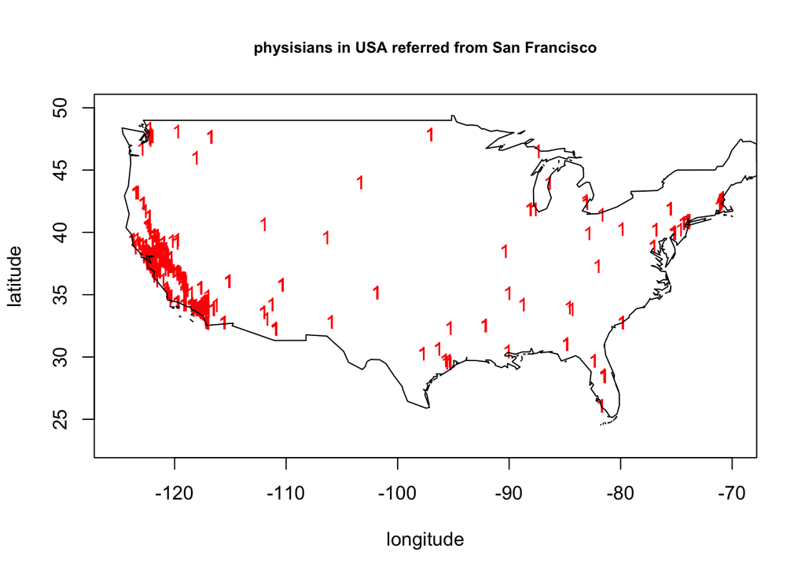

```r
outNode <- Edge_SF[,.(V2)]
zip <- DT[outNode]$"Zip Code"
zip = substr(zip, start = 1, stop = 5)

data(zipcode)   # this contains the locations of zip codes
zipcode = as.data.table(zipcode); setkey(zipcode, zip)
loc1 =  zipcode[zip, c("latitude", "longitude"), with = F]
loc1 = loc1[complete.cases(loc1)]
loc1 = data.frame(loc1)
plot(loc1[,2],loc1[,1], pch="1",col="red", xlim= c(-125, -70), ylim= c(23,50),
     xlab = "longitude", ylab ="latitude")
title(main="physisians in USA referred from San Francisco",cex.main=0.8)
map(database = 'world', region = c('usa'),fill=F, add = T)
```

### Part 2, show the referral network confined to network among physicians in SF, Trying to show the relationship between network and total payment from Medicare

```r
library(igraph)
Edge_SF1 <- Edge_SF[V2 %in% V1]
paylevel <- function(x){
    high <- quantile(x,probs = 0.90)
    high_medium <- quantile(x,probs = 0.70)
    low_medium <- quantile(x,probs = 0.30)
    low <- quantile(x,probs = 0.10)
    y <- as.character(x)
    y[which(x>=high)]="high"
    y[which(x<high &x>= high_medium)] ="high_medium"
    y[which(x<high_medium &x>= low_medium)] ="medium"
    y[which(x<low_medium &x>= low)] ="low_medium"
    y[which(x<low)] ="low"
    y[is.na(x)]="NA"
    return(y)
}
Payment_SF <-Payment_SF[,.(NPI,totalPay,logPay,payLevel=paylevel(totalPay))]

el=as.matrix(Edge_SF1)[,1:2] #igraph needs the edgelist to be in matrix format
g=graph.edgelist(el,directed = F) # this creates a graph.
g= simplify(g)  # removes any self loops and multiple edges
vcount(g)
```

```
## [1] 1000
```

```r
ecount(g)
```

```
## [1] 4742
```

```r
ids <- unique(Edge_SF1[,.(V1)])
cities <- DT[ids, mult="first"]$City  ## cannot just simply pick one, having multiple address.
sort(table(cities), decreasing=TRUE)[1:30]
```

```
## cities
##       SAN FRANCISCO          SANTA ROSA           DALY CITY
##                 743                  24                  10
##          BURLINGAME              FRESNO           SAN MATEO
##                   9                   8                   8
##          SACRAMENTO           GREENBRAE        REDWOOD CITY
##                   5                   4                   4
##            PARADISE            SAN JOSE               SELMA
##                   3                   3                   3
##             ALAMEDA             ANTIOCH             HANFORD
##                   2                   2                   2
##           KENTFIELD              MERCED             OAKLAND
##                   2                   2                   2
##             REDDING            ROSEBURG SOUTH SAN FRANCISCO
##                   2                   2                   2
##        WALNUT CREEK       CASTRO VALLEY       COEUR D ALENE
##                   2                   1                   1
##        CORTE MADERA             FREMONT           HOLLISTER
##                   1                   1                   1
##                KATY                LODI          LOMA LINDA
##                   1                   1                   1
```

```r
states <- DT[ids]$State## cannot just simply pick one, having multiple address.
sort(table(states), decreasing=TRUE)  # most are in CA, many are out sides of SF
```

```
## states
##   CA   TX   AZ   OR   DC   ID   IL   NJ   NV   WA
## 3348    4    3    2    1    1    1    1    1    1
```

```r
clust <- clusters(g)
clust$csize
```

```
##  [1]   4 868  20   3  24   5   2   2   2  18   2   2   2   3   2   7   4
## [18]   3   2   2   4   2   2   2   2   3   2   2   2   2
```

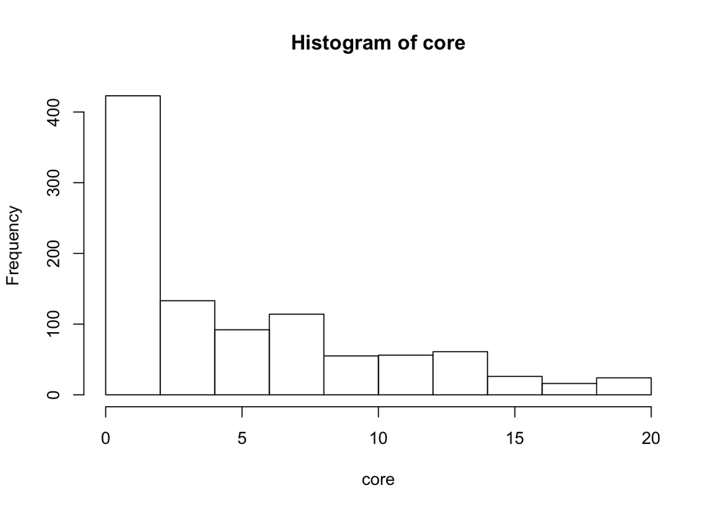

```r
core = graph.coreness(g)  # talk about core.
hist(core)
```

```r
sum(core>3)
```

```
## [1] 485
```

```r
g1 = induced.subgraph(graph = g,vids = V(g)[core>3])  # talk about induced subgraphs.
clust1 <- clusters(g1)
clust1$csize
```

```
## [1] 455  17  13
```

```r
## look at the biggest connected component
g2 <- induced_subgraph(g1,vids = names(which(clust1$membership==1)))
clusters(g2)$csize
```

```
## [1] 455
```

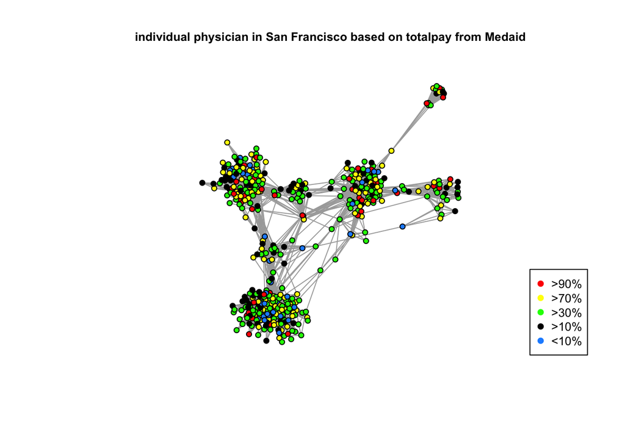

```r
layout(1)
v.colors <- as.character(Payment_SF[V(g1)]$payLevel)
v.colors[v.colors=="high"]="red"
v.colors[v.colors=="low"] ="dodgerblue"
v.colors[v.colors=="high_medium"]="yellow"
v.colors[v.colors=="medium"]="green"
v.colors[v.colors=="low_medium"]="black"

set.seed(42)
plot(g2,layout = layout.fruchterman.reingold, vertex.label = NA,
     edge.arrow.size=0.05,  vertex.size=4,
     vertex.color=v.colors)
title(main="individual physician in San Francisco based on totalpay from Medaid",cex.main=0.8)
legend("bottomright",legend=c(">90%",">70%",">30%",">10%","<10%"),
                    col=c("red","yellow","green","black","dodgerblue"), pch=19,
       border = "white",cex =0.8)
```

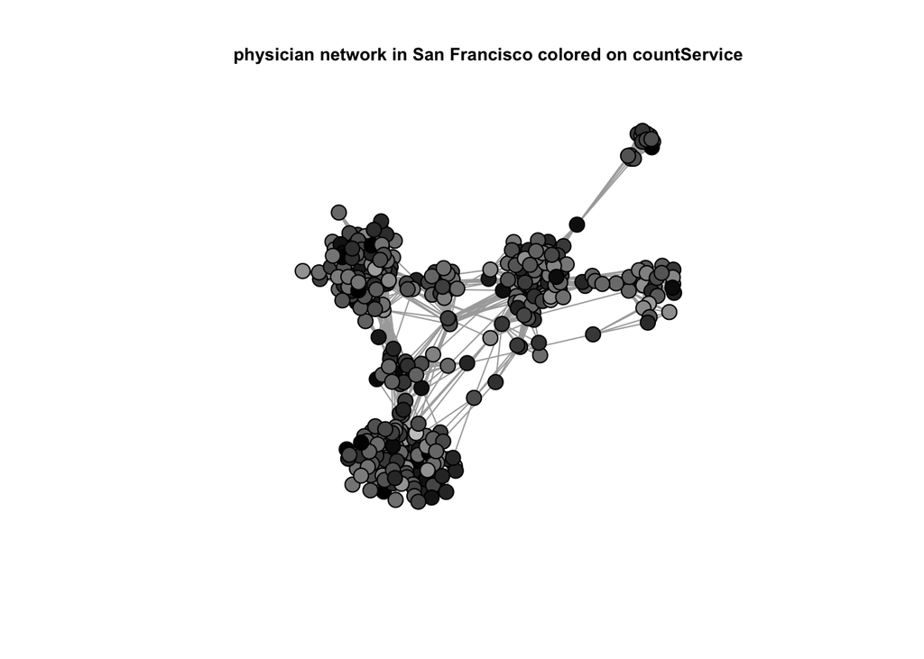

```r
Payment_NPI_SF <- Payment_NPI_ca[NPPES_PROVIDER_CITY=="SAN FRANCISCO"]
NPI_servicecount <- Payment_NPI_SF[,.(countService = sum(LINE_SRVC_CNT)),by=NPI]
NPI_servicecount$logCount <- log(NPI_servicecount$countService)

set.seed(42)
logCount <- NPI_servicecount[V(g2)]$logCount
plot(g2,layout = layout.fruchterman.reingold, vertex.label = NA,
     edge.arrow.size=0.05,  vertex.size=8,
     vertex.color = grey((logCount - min(logCount))/(max(logCount) - min(logCount))) )
title(main="physician network in San Francisco colored on countService",cex.main=0.8)
```

Finding: results show that the clusters in physician referral network are not consistent with the total pay or total number of services. Need to further Explore those high-paid/high service giver may be hubs of the network?

## Part 3, Results based on Spectral clustering.

– using spectral clustering to partition the network; – Looking the nodes features, and inteprete the results

```r
#get.adjacency(graph, type=c("both", "upper", "lower"),  attr=NULL, names=TRUE, binary=FALSE, sparse=FALSE)
library(Matrix)
Adj2 <- get.adjacency(g2)  ## This is 'dgCMatrix' -- i, p
Matrix::isSymmetric(Adj2)
```

```
## [1] TRUE
```

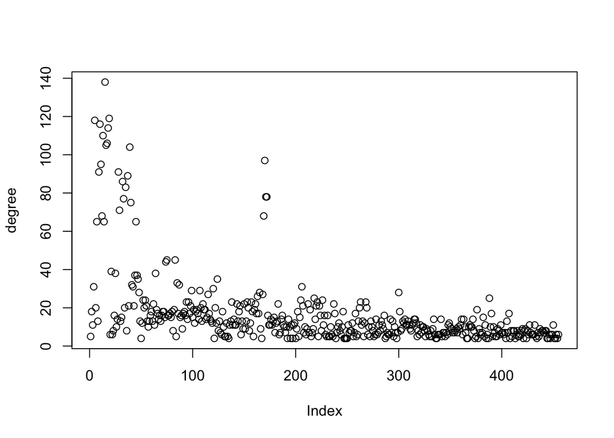

```r
degree <- Matrix::rowSums(Adj2)
plot(degree)
```

```r
source("~/Stat/Courses/Physisian_Referral_Network/RScripts/regularSpec/specClust.R")
specClust <- specClust(Adj2,nBlocks = 10, verbose = T)
```

```r
V(g2)$label.dist <- 0
set.seed(42)
plot(g2,layout = layout.fruchterman.reingold, vertex.label = NA,
     edge.arrow.size=0.05,  vertex.size=10,
     vertex.color=specClust$cluster)
specClust$eigenVals
```

```
##  [1] 0.6216877 0.5385939 0.5060015 0.4043161 0.3781330 0.3656144 0.3388099
##  [8] 0.3237747 0.3116689 0.3038802 0.2981098
```

```r
table(specClust$cluster)
```

```
##
##   1   2   3   4   5   6   7   8   9  10
##  19  81  72  35  28  54  32 104  16  14
```

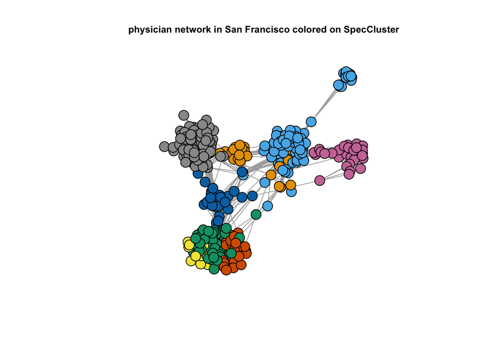

```r
title(main="physician network in San Francisco colored on SpecCluster",cex.main=0.8)
```

```r
##  Trying to interpret the clusters
#1 zip code seems strongly correlated with the network clusterss
zip_SF <- substr(DT[names(V(g2)),mult="first"]$`Zip Code`,1,5)
#table(specClust$cluster,DT[names(V(g2)),mult="first"]$`Primary specialty`)
tab <- table(specClust$cluster,substr(DT[names(V(g2)),mult="first"]$`Zip Code`,1,5))
for( i in 1:10){
    print(colnames(tab)[order(tab[i,],decreasing = T)[1:4]])
}
```

```
## [1] "94110" "94143" "94116" "94010"
## [1] "94117" "94109" "94132" "94133"
## [1] "94115" "94118" "94110" "95405"
## [1] "94115" "95405" "94118" "95816"
## [1] "94115" "94114" "94118" "94109"
## [1] "94115" "94110" "94114" "94118"
## [1] "94108" "94133" "94134" "94115"
## [1] "94143" "94110" "94115" "94117"
## [1] "94117" "94062" "94015" "94109"
## [1] "94904" "94118" "94143" "94010"
```

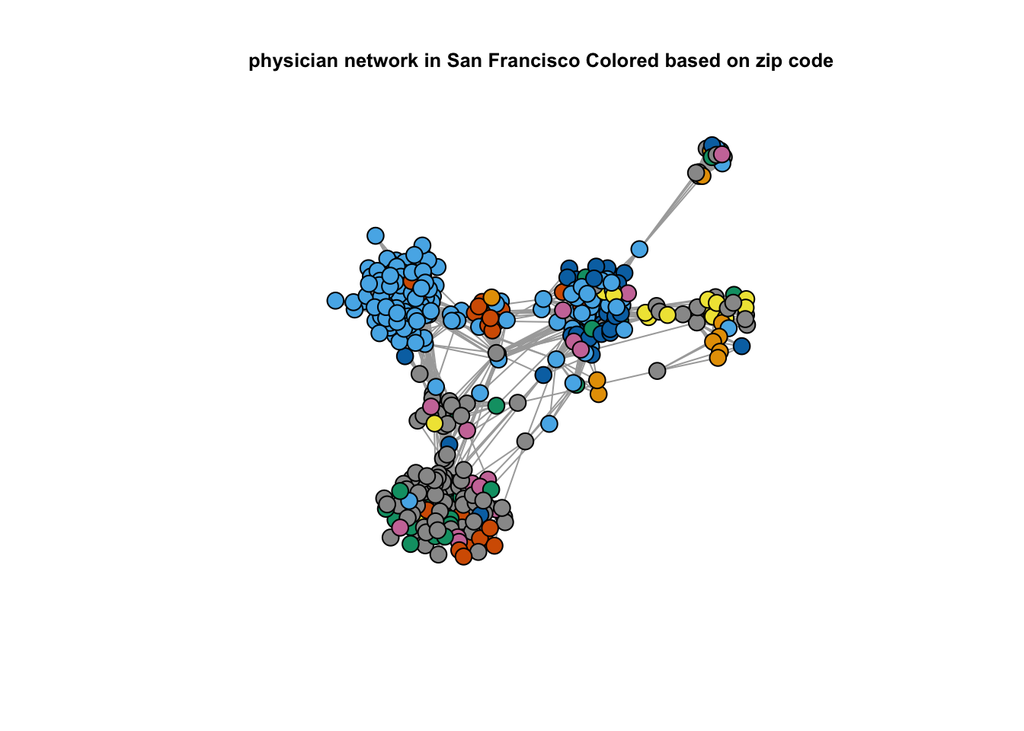

```r
set.seed(42)
plot(g2,layout = layout.fruchterman.reingold, vertex.label = NA,
     edge.arrow.size=0.05,  vertex.size=8,
     vertex.color=as.factor(zip_SF))
title(main="physician network in San Francisco Colored based on zip code",cex.main=0.8)
```

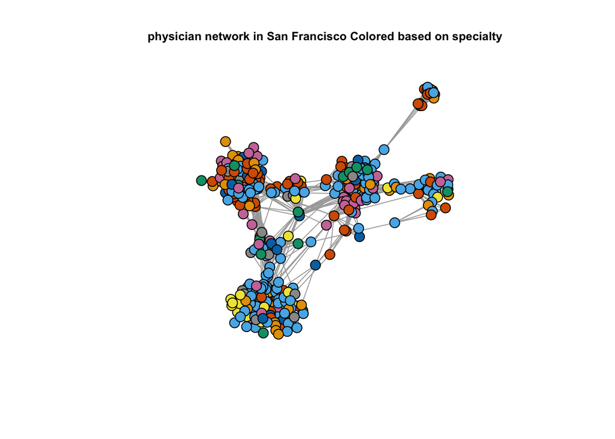

```r
set.seed(42)
plot(g2,layout = layout.fruchterman.reingold, vertex.label = NA,
     edge.arrow.size=0.05,  vertex.size=8,
     vertex.color=as.factor(DT[names(V(g2)),mult="first"]$`Primary specialty`))
title(main="physician network in San Francisco Colored based on specialty", cex.main=0.8)
```

Findings, Specialties don’t correspond to clusters in the network of physisians, they are scattly distributed in the network. It seems that most correlated feature is zip code.

### Part 5

Potential direction to try: – construct specialty network, individual physisian may not be very informative. specialty is a concentration version of the network. – constrain the data further to a zip code, to exclude the location effect on network. – Look at referral network of 60-day or 30-day to exclude the long range referral.